# Lab 5: Multicollinearity and VIF

MATH 4780 / MSSC 5780 Regression Analysis

Author

Mehdi Maadooliat

**NoteCourse data**

This lab uses objects in `regression_datasets.rda`. Put the `.qmd` file and `regression_datasets.rda` in the same folder before rendering or working through the lab.

## Learning goals

Diagnose multicollinearity using correlations and variance inflation factors (VIFs), understand its effect on coefficient estimates, and compare nested models.

```r
library(ggplot2)
library(car)
```

## 1. Hospital manpower data

This is the same hospital manpower dataset used in the 2026 multicollinearity slides.

- (y): monthly man-hours
- (x_1): average daily patient load
- (x_2): monthly X-ray exposures
- (x_3): monthly occupied bed days
- (x_4): eligible population in the area / 1000
- (x_5): average length of patient stay in days

```r
manpower
```

```
       y    x1    x2    x3    x4    x5
1    567  15.6  2463   473  18.0  4.45
2    697  44.0  2048  1340   9.5  6.92
3   1033  20.4  3940   620  12.8  4.28
4   1604  18.7  6505   568  36.7  3.90
5   1611  49.2  5723  1498  35.7  5.50
6   1613  44.9 11520  1366  24.0  4.60
7   1854  55.5  5779  1687  43.3  5.62
8   2161  59.3  5969  1640  46.7  5.15
9   2306  94.4  8461  2872  78.7  6.18
10  3504 128.0 20106  3655 180.5  6.15
11  3572  96.0 13313  2912  60.9  5.88
12  3741 131.4 10771  3921 103.7  4.88
13  4027 127.2 15543  3866 126.8  5.50
14 10344 252.9 36194  7684 157.7  7.00
15 11732 409.2 34703 12446 169.4 10.78
16 15415 463.7 39204 14098 331.4  7.05
17 18854 510.2 86533 15524 371.6  6.35
```

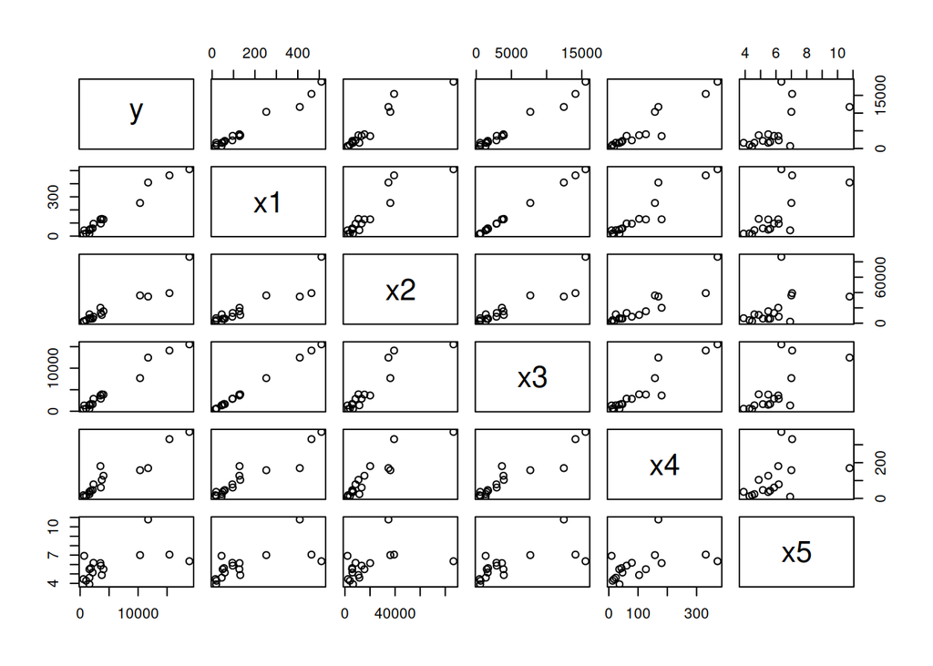

```r
pairs(manpower)
```

## 2. The full model

```r
fit_full <- lm(y ~ ., data = manpower)
summary(fit_full)
```

```
Call:
lm(formula = y ~ ., data = manpower)

Residuals:
   Min     1Q Median     3Q    Max
-611.9 -431.4  -70.8  332.6 1576.1

Coefficients:
             Estimate Std. Error t value Pr(>|t|)
(Intercept) 1962.9482  1071.3617    1.83    0.094 .
x1           -15.8517    97.6530   -0.16    0.874
x2             0.0559     0.0213    2.63    0.023 *
x3             1.5896     3.0921    0.51    0.617
x4            -4.2187     7.1766   -0.59    0.569
x5          -394.3141   209.6395   -1.88    0.087 .
---
Signif. codes:  0 '***' 0.001 '**' 0.01 '*' 0.05 '.' 0.1 ' ' 1

Residual standard error: 642 on 11 degrees of freedom
Multiple R-squared:  0.991, Adjusted R-squared:  0.987
F-statistic:  238 on 5 and 11 DF,  p-value: 8.07e-11
```

Do any coefficient signs or significance tests seem surprising relative to the marginal relationships in the pairs plot?

## 3. Correlations among the predictors

```r
round(cor(manpower[-1]), 3)
```

```
      x1    x2    x3    x4    x5
x1 1.000 0.907 1.000 0.936 0.671
x2 0.907 1.000 0.907 0.910 0.447
x3 1.000 0.907 1.000 0.933 0.671
x4 0.936 0.910 0.933 1.000 0.463
x5 0.671 0.447 0.671 0.463 1.000
```

Which pairs of predictors appear most strongly correlated? Why is a correlation matrix not sufficient to diagnose every form of multicollinearity?

## 4. Variance inflation factors

```r
vif_full <- car::vif(fit_full)
vif_full
```

```
     x1      x2      x3      x4      x5
9597.57    7.94 8933.09   23.29    4.28
```

where (R_j^2) is obtained by regressing predictor (X_j) on all the other predictors.

Verify one VIF manually.

```r
aux_x3 <- lm(x3 ~ x1 + x2 + x4 + x5, data = manpower)
1 / (1 - summary(aux_x3)$r.squared)
```

```
[1] 8933
```

```r
vif_full["x3"]
```

```
  x3
8933
```

Explain why a large (R_j^2) in the auxiliary regression inflates the variance of (_j).

## 5. Remove one redundant predictor

The 2026 slides investigate a model without `x3`.

```r
fit_no_x3 <- update(fit_full, . ~ . - x3)

summary(fit_no_x3)
```

```
Call:
lm(formula = y ~ x1 + x2 + x4 + x5, data = manpower)

Residuals:
   Min     1Q Median     3Q    Max
-703.7 -331.6  -83.3  222.8 1582.6

Coefficients:
             Estimate Std. Error t value Pr(>|t|)
(Intercept) 2161.9617   967.8711    2.23    0.045 *
x1            34.2839     4.8965    7.00  1.4e-05 ***
x2             0.0567     0.0205    2.76    0.017 *
x4            -6.6002     5.3106   -1.24    0.238
x5          -440.2973   183.6965   -2.40    0.034 *
---
Signif. codes:  0 '***' 0.001 '**' 0.01 '*' 0.05 '.' 0.1 ' ' 1

Residual standard error: 622 on 12 degrees of freedom
Multiple R-squared:  0.991, Adjusted R-squared:  0.987
F-statistic:  317 on 4 and 12 DF,  p-value: 4.75e-12
```

```r
car::vif(fit_no_x3)
```

```
  x1   x2   x4   x5
25.7  7.9 13.6  3.5
```

Compare the models with a nested (F)-test.

```r
anova(fit_no_x3, fit_full)
```

```
Analysis of Variance Table

Model 1: y ~ x1 + x2 + x4 + x5
Model 2: y ~ x1 + x2 + x3 + x4 + x5
  Res.Df     RSS Df Sum of Sq    F Pr(>F)
1     12 4644015
2     11 4535052  1    108962 0.26   0.62
```

1. How do the coefficient estimates and standard errors change?
2. How do the VIFs change?
3. Is deleting `x3` justified by the nested (F)-test alone?
4. What substantive information might be lost by deleting a predictor?

## 6. Prediction versus coefficient stability

```r
c(
  full_R2 = summary(fit_full)$r.squared,
  reduced_R2 = summary(fit_no_x3)$r.squared
)
```

```
   full_R2 reduced_R2
     0.991      0.991
```

Why can a model have substantial multicollinearity and still fit the observed responses well? Why is extrapolation particularly risky?

## 7. A matrix view: condition number

VIFs diagnose predictor-specific inflation. A complementary global diagnostic comes from the geometry of the standardized predictor matrix.

```r
X <- model.matrix(fit_full)[, -1, drop = FALSE]
Xz <- scale(X)

eigenvalues <- eigen(cor(Xz), symmetric = TRUE)$values
condition_index <- sqrt(max(eigenvalues) / eigenvalues)

data.frame(
  eigenvalue = eigenvalues,
  condition_index = condition_index
)
```

```
  eigenvalue condition_index
1   4.197117            1.00
2   0.667484            2.51
3   0.094633            6.66
4   0.040712           10.15
5   0.000054          278.87
```

Why can a very small eigenvalue indicate that some linear combination of the predictors is nearly redundant?

## Takeaway

Multicollinearity is primarily a problem of **unstable estimation and interpretation**, not necessarily poor in-sample fit. VIF quantifies how much the variance of an individual coefficient is inflated by linear dependence among the predictors.